# Community Detection of International Trade for Battery and Electric Network

Network Analysis of 10 years Trade Data for top producers of Copper, Lithium, and Graphite

Abhinav Kumar https://www.linkedin.com/in/abhinavkumar2603/  
2022-05-12

This study has been designed to explore the trade relations that have developed over 10 years from 2012 to 2021 for top producers of Copper, Lithium, and Graphite. These commodities have been selected to study how has the battery and electric economy evolved. The data has been extracted using UN Comtrade API. The commodities have been selected using international HS codes for trade. The commodities selected are in the input form rather than value added finished products to understand the production pattern of producers and consumption pattern of importers.

```r
library(readr)
library(tidyverse)
library(igraph)
library(statnet)
library(ITNr)
library(concordance)
library(corrr)
trade <- read_csv(file.choose())
```

### solve problem of duplication arising becuase of aggregate function…

```r
# Converting all Imports to Exports by interchanging the reporter and partner

trade %>%
  filter(trade_flow == "Import") %>%
  mutate(aux = reporter, reporter = partner, partner = aux,
         trade_flow = "Export") %>%
  select(-aux) -> tmp
rbind(trade, tmp) %>%
  filter(trade_flow == "Export") -> total_trade_clean

total_trade_clean <- total_trade_clean %>% group_by(commodity_code)

head(total_trade_clean)
```

```
# A tibble: 6 x 9
# Groups:   commodity_code [1]
   year trade_flow reporter_iso reporter partner_iso partner
  <dbl> <chr>      <chr>        <chr>    <chr>       <chr>
1  2012 Export     CHL          Chile    BRA         Brazil
2  2012 Export     CHL          Chile    BGR         Bulgaria
3  2012 Export     CHL          Chile    CAN         Canada
4  2012 Export     CHL          Chile    CHN         China
5  2012 Export     CHL          Chile    FIN         Finland
6  2012 Export     CHL          Chile    DEU         Germany
# ... with 3 more variables: commodity_code <dbl>, commodity <chr>,
#   trade_value_usd <dbl>
```

```r
unique(total_trade_clean$commodity_code)
```

```
[1]   2603   7404   7406 282520 283691   2504   3801
```

```r
unique(total_trade_clean$commodity)
```

```
 [1] "Copper ores and concentrates"
 [2] "Copper; waste and scrap"
 [3] "Copper; powders and flakes"
 [4] "Copper waste and scrap."
 [5] "Lithium oxide and hydroxide"
 [6] "Carbonates; lithium carbonate"
 [7] "Lithium oxide & hydroxide"
 [8] "Lithium carbonates"
 [9] "Graphite; natural"
[10] "Artificial graphite; colloidal or semi-colloidal graphite; preparations based on graphite or other carbon in the form of pastes, blocks, plates or other semi-manufactures"
[11] "Natural graphite."
[12] "Artificial graphite; colloidal or semi-colloidal graphite; preparations based on graphite or other carbon in the form of pastes, blocks, plates or other semi-manufactures."
[13] "Copper ores and concentrates."
[14] "Copper powders and flakes."
```

Graphite <- 3801 2504 Lithium <- 283691 282520 Copper <- 2603 7406 7404

```r
graphite_trade_clean <- total_trade_clean[total_trade_clean$commodity_code == c("3801", "2504"),]
head(graphite_trade_clean)
```

```
# A tibble: 6 x 9
# Groups:   commodity_code [1]
   year trade_flow reporter_iso reporter partner_iso partner
  <dbl> <chr>      <chr>        <chr>    <chr>       <chr>
1  2012 Export     CHN          China    DZA         Algeria
2  2012 Export     CHN          China    AZE         Azerbaijan
3  2012 Export     CHN          China    AUS         Australia
4  2012 Export     CHN          China    BGD         Bangladesh
5  2012 Export     CHN          China    BRA         Brazil
6  2012 Export     CHN          China    MMR         Myanmar
# ... with 3 more variables: commodity_code <dbl>, commodity <chr>,
#   trade_value_usd <dbl>
```

```r
lithium_trade_clean <- total_trade_clean[total_trade_clean$commodity_code == c("283691", "282520"),]
head(lithium_trade_clean)
```

```
# A tibble: 6 x 9
# Groups:   commodity_code [2]
   year trade_flow reporter_iso reporter  partner_iso partner
  <dbl> <chr>      <chr>        <chr>     <chr>       <chr>
1  2012 Export     AUS          Australia SLB         Solomon Isds
2  2014 Export     AUS          Australia NCL         New Caledonia
3  2015 Export     AUS          Australia USA         USA
4  2012 Export     AUS          Australia PNG         Papua New Guinea
5  2013 Export     AUS          Australia JPN         Japan
6  2014 Export     AUS          Australia NZL         New Zealand
# ... with 3 more variables: commodity_code <dbl>, commodity <chr>,
#   trade_value_usd <dbl>
```

```r
copper_trade_clean <- total_trade_clean[total_trade_clean$commodity_code == c("2603", "7406", "7404"),]
head(copper_trade_clean)
```

```
# A tibble: 6 x 9
# Groups:   commodity_code [1]
   year trade_flow reporter_iso reporter partner_iso partner
  <dbl> <chr>      <chr>        <chr>    <chr>       <chr>
1  2012 Export     CHL          Chile    BRA         Brazil
2  2012 Export     CHL          Chile    CHN         China
3  2012 Export     CHL          Chile    JPN         Japan
4  2012 Export     CHL          Chile    MEX         Mexico
5  2012 Export     CHL          Chile    PHL         Philippines
6  2012 Export     CHL          Chile    ESP         Spain
# ... with 3 more variables: commodity_code <dbl>, commodity <chr>,
#   trade_value_usd <dbl>
```

## Week 1

```r
# creating igraph network

X <- data.frame("From" = total_trade_clean$reporter,
                "To" = total_trade_clean$partner,
                "weight" = total_trade_clean$trade_value_usd)

net.ig <- graph.data.frame(X, directed = TRUE)
E(net.ig)$weight <- total_trade_clean$trade_value_usd

adj <- get.adjacency(net.ig, sparse = FALSE)

summary(net.ig)
```

```
IGRAPH e1fe41a DNW- 212 22269 --
+ attr: name (v/c), weight (e/n)
```

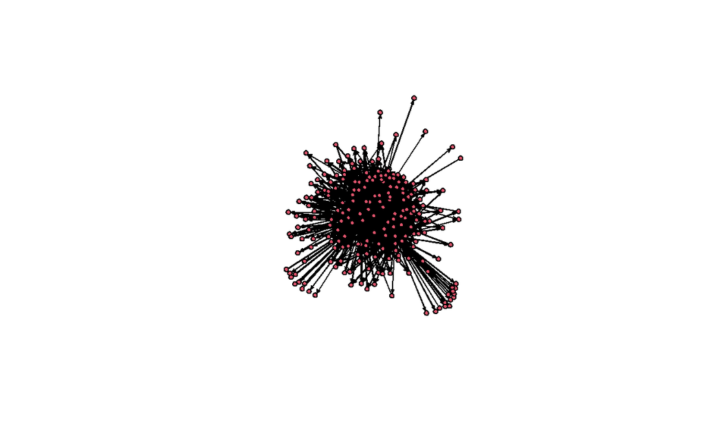

```r
# Coercing igraph object to statnet object

network <- intergraph::asNetwork(net.ig)

# plotting the network
set.seed(64823)
plot(network)
```

## Network Structure

```r
print(paste0("The number of vertices in the network is:",vcount(net.ig)))
```

```
[1] "The number of vertices in the network is:212"
```

```r
print(paste0("The number of edges in the network is:",ecount(net.ig)))
```

```
[1] "The number of edges in the network is:22269"
```

```r
#exploring the dyad census
dyad_census(net.ig)
```

```
$mut
[1] 716

$asym
[1] 681

$null
[1] 20969
```

```r
triad.census(network)
```

```
         003   012   102 021D 021U 021C  111D  111U 030T 030C   201
[1,] 1356065 72870 58663 6833 4943 4526 15256 17223   61   14 23448
     120D 120U 120C  210  300
[1,]  261  379  614 2324 2140
```

As per triad census, there are 1356065 empty triads. 72870 one edge directed triads. 58663 directed one edge mutual triads. 6833 triads exist where 6833 countries with downward asymmetric relationship are exporting to 13,666 (could be duplicated multiple times) countries in those triads. 4943 triads exist with upward directed asymmetric export relationship from 9,886 countries. There are 14 closed triads. A total of 61 transitive triads exist in the trade network.

```r
is_directed(net.ig)
```

```
[1] TRUE
```

```r
is_weighted(net.ig)
```

```
[1] TRUE
```

```r
is_bipartite(net.ig)
```

```
[1] FALSE
```

The network developed is directed due the nature of trade i.e. export and the network is weighted with with the export trade value in USD.

```r
#get global clustering cofficient: igraph
transitivity(net.ig, type="global")
```

```
[1] 0.1939447
```

The Global transitivity of the network is 0.19, which is the overall proportion of triads among all connected triads.

```r
#get average local clustering coefficient: igraph
transitivity(net.ig, type="average")
```

```
[1] 0.9202577
```

```r
transitivity(net.ig, type="local")
```

```
  [1] 0.25633803 0.08514140 0.13196044 0.72794118 0.09038031
  [6] 0.07994496 0.39271255 0.17357246 0.51746032 0.58064516
 [11] 0.22303850 0.93333333 0.78362573 0.20390720 0.22068763
 [16] 0.10927748 0.19063545 0.35709294 0.24714662 1.00000000
 [21] 0.97777778 0.91176471 1.00000000 0.96153846 0.95000000
 [26] 1.00000000 0.98717949 0.96703297 0.98901099 0.89705882
 [31] 1.00000000 1.00000000 0.97222222 0.95833333 0.97802198
 [36] 1.00000000 0.89705882 0.97802198 0.89705882 0.97222222
 [41] 0.98901099 1.00000000 0.84558824 0.97435897 1.00000000
 [46] 1.00000000 1.00000000 0.93333333 0.95238095 0.97777778
 [51] 1.00000000 1.00000000 1.00000000 1.00000000 1.00000000
 [56] 1.00000000 1.00000000 1.00000000 1.00000000 1.00000000
 [61] 1.00000000 1.00000000 1.00000000 1.00000000 1.00000000
 [66] 1.00000000 1.00000000 1.00000000 0.98717949 1.00000000
 [71] 0.94871795 1.00000000        NaN 1.00000000 0.97777778
```

[output cut: 28 more lines]

Path Lengths

```r
average.path.length(net.ig)
```

```
[1] 76037.51
```

The distances function enables us to look at the distance traveled between two nodes. Let’s explore some distances between two countries USA and India

```r
distances(net.ig,"India", "USA")
```

```
      USA
India  10
```

```r
gd<- all_shortest_paths(net.ig,"India", "USA", weights = NA)
gd$nrgeo# geodesic distance.
```

```
  [1] 16 41 38  5 52 70 19 24 19 18 25  8  1 20 21  1 30 21  2  0  7
 [22] 13 12  5 13  0  4  2 20 18  4  5 13  6 15  4 14 10 15  5 17  4
 [43] 15 17 19 11 18 14 14 14  3  8  0  0  3  0  4  8  4  0 20  0  1
 [64] 11  0  0  0  1  3  0  7  1  0  7  9  3  4  2  3  0  0  2  6  6
 [85] 11 20 17  0  7  0  2  0  0  0  0  0 16  0 15  6 11  2  1  0 12
[106]  0  7  3  1  7  5 14  2  4  1 20  4  0 16  7  0  0  0  2 11  0
[127] 11  0  0  0 18  7  0 19 16  1  0  2  4  0  7  1  0  1  0  5  1
[148]  3  0  4  6  4  0  0  0  0  0  1  0  0  0  0  0  0  0  0  0  0
[169]  2  3  1  6  2  0 15  4  0  0  8  0 20  0  2  1  1  1  0  4  0
[190]  0  1 16 14  0  0  0  0  0  0  0  0  5  0  0  0  0  0  0  0  0
[211]  0  0
```

```r
gd<- all_shortest_paths(net.ig,"India", "USA")
gd$nrgeo
```

```
  [1] 1 1 1 0 1 1 0 1 1 0 1 1 1 1 0 1 1 1 1 1 0 1 1 0 0 1 1 0 1 1 0 0
 [33] 1 1 0 1 1 0 1 1 0 1 1 1 0 1 0 2 1 1 0 1 0 0 0 0 1 0 0 0 0 0 0 0
 [65] 0 0 0 0 1 0 1 0 0 0 0 0 1 0 1 1 0 0 1 0 0 0 0 0 0 0 1 1 0 1 0 1
 [97] 1 0 0 1 0 1 0 0 1 0 1 0 0 1 1 0 0 0 0 1 0 0 1 0 0 0 0 0 1 0 1 0
[129] 0 0 0 0 0 1 0 0 0 0 0 0 1 0 0 1 0 0 0 0 0 1 1 0 0 0 1 0 0 0 0 0
[161] 0 0 1 0 0 0 0 0 1 1 0 0 1 1 0 0 0 0 0 0 0 0 0 0 0 0 0 0 0 1 0 1
[193] 0 0 0 0 0 0 0 0 0 1 0 0 0 0 0 0 1 0 0 0
```

## Density

```r
graph.density(net.ig)
```

```
[1] 0.4978315
```

```r
graph.density(net.ig, loops=TRUE)
```

```
[1] 0.4954833
```

```r
graph.density(net.ig)
```

```
[1] 0.4978315
```

##Degree

```r
igraph::degree(net.ig)
```

```
                                 Chile
                                  1527
                               Germany
                                  3575
                                 Japan
                                  1781
                                 Congo
                                    74
                                   USA
                                  3518
                                 China
                                  5955
                                Zambia
                                   232
                    Russian Federation
                                  1735
                             Australia
                                   485
                             Argentina
                                   396
                                Brazil
                                  1312
                              Zimbabwe
                                    60
                              Portugal
                                   238
                           Netherlands
                                  1409
                               Belgium
                                  1514
                                 India
                                  2177
                                Canada
                                  1411
                                Mexico
                                   748
                               Ukraine
                                   757
      Bolivia (Plurinational State of)
                                    99
```

[output cut: 369 more lines]

```
                                     1
                                Tuvalu
                                     1
                         Guinea-Bissau
                                     1
                          Solomon Isds
                                     1
                               Bunkers
                                     1
                               Comoros
                                     1
                     Equatorial Guinea
                                     5
             Saint Pierre and Miquelon
                                     1
```

Create a Data Frame

```r
trade.nodes<-data.frame(name=V(net.ig)$name, degree=igraph::degree(net.ig))
```

## In Degree and Out Degree

```r
trade.nodes<-trade.nodes %>%
    mutate(indegree=igraph::degree(net.ig, mode="in", loops=FALSE),
           outdegree=igraph::degree(net.ig, mode="out", loops=FALSE))
```

Summarize by Group

```r
trade.nodes%>%
  group_by(name)%>%
  summarise_all(funs(mean, n()))
```

```
# A tibble: 212 x 7
   name   degree_mean indegree_mean outdegree_mean degree_n indegree_n
   <chr>        <dbl>         <dbl>          <dbl>    <int>      <int>
 1 Afgha~          11            10              1        1          1
 2 Alban~          28             6             22        1          1
 3 Alger~          28            26              2        1          1
 4 Andor~           2             2              0        1          1
 5 Angola          41            35              6        1          1
 6 Angui~           3             0              3        1          1
 7 Antig~          16             5             11        1          1
 8 Areas~          75             6             69        1          1
 9 Argen~         396           226            166        1          1
10 Armen~          59            31             28        1          1
# ... with 202 more rows, and 1 more variable: outdegree_n <int>
```

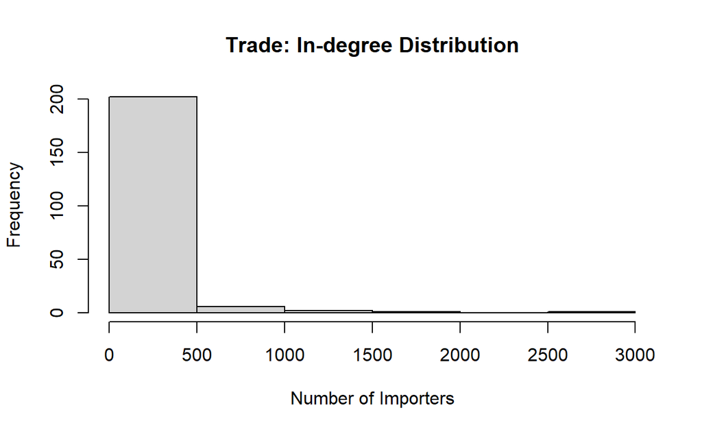

```r
#create a histogram of trade Indegree
hist(trade.nodes$indegree, main="Trade: In-degree Distribution", xlab="Number of Importers")
```

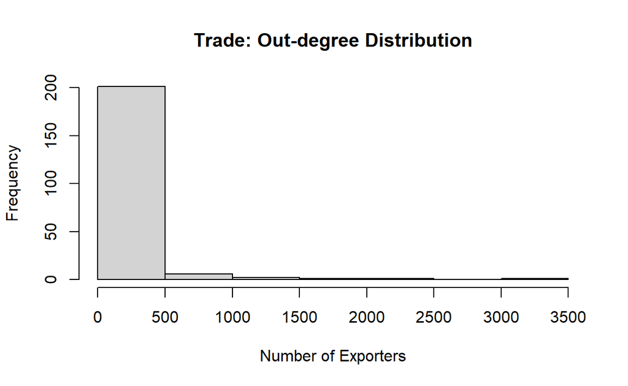

```r
#create a histogram of trade Indegree
hist(trade.nodes$outdegree, main="Trade: Out-degree Distribution", xlab="Number of Exporters")
```

## Network Degree Centrality

```r
#get network centralization score: igraph
centr_degree(net.ig, loops = FALSE, mode="in")$centralization
```

```
[1] 12.47748
```

```r
centr_degree(net.ig, loops = FALSE, mode="out")$centralization
```

```
[1] 14.40601
```

##Highest and Lowest In and Out degrees

```r
trade.nodes%>%
  arrange(desc(indegree))%>%
  slice(1:5)
```

```
                                 name degree indegree outdegree
China                           China   5955     2725      3130
Germany                       Germany   3575     1815      1760
USA                               USA   3518     1319      2199
Japan                           Japan   1781     1153       628
Russian Federation Russian Federation   1735      865       868
```

```r
trade.nodes%>%
  arrange(indegree)%>%
  slice(1:5)
```

```
                               name degree indegree outdegree
Faeroe Isds             Faeroe Isds      1        0         1
Gibraltar                 Gibraltar      1        0         1
Other Africa, nes Other Africa, nes      2        0         2
Kiribati                   Kiribati      2        0         2
Montserrat               Montserrat      3        0         3
```

```r
trade.nodes%>%
  arrange(desc(outdegree))%>%
  slice(1:5)
```

```
           name degree indegree outdegree
China     China   5955     2725      3130
USA         USA   3518     1319      2199
Germany Germany   3575     1815      1760
India     India   2177      862      1315
Belgium Belgium   1514      472      1042
```

```r
trade.nodes%>%
  arrange(outdegree)%>%
  slice(1:5)
```

```
                                 name degree indegree outdegree
State of Palestine State of Palestine      7        7         0
Andorra                       Andorra      2        2         0
Chad                             Chad      5        5         0
Cocos Isds                 Cocos Isds      1        1         0
South Sudan               South Sudan      1        1         0
```

##Network Status

```r
#add eigenvector centrality to node measures
temp <- centr_eigen(net.ig,directed=T)
trade.nodes$eigen<-temp$vector
#arrange descending and return top 5 nodes
arrange(trade.nodes, desc(eigen)) %>%
  slice(1:5)
```

```
           name degree indegree outdegree     eigen
China     China   5955     2725      3130 1.0000000
Germany Germany   3575     1815      1760 0.6629672
USA         USA   3518     1319      2199 0.6151251
Japan     Japan   1781     1153       628 0.5107358
India     India   2177      862      1315 0.4693189
```

##Derived and Reflected Centrality

```r
matrix <- as.matrix(as_adjacency_matrix(net.ig, attr = "weight"))
#square the adjacency matrix
matsq<-t(matrix) %*% matrix
#Calculate the proportion of reflected centrality.
trade.nodes$rc<-diag(matsq)/rowSums(matsq)
#replace missing values with 0
trade.nodes$rc<-ifelse(is.nan(trade.nodes$rc),0,trade.nodes$rc)
#Calculate received eigenvalue centrality
trade.nodes$eigen.rc<-trade.nodes$eigen*trade.nodes$rc
#Calculate the proportion of derived centrality.
trade.nodes$dc<-1-diag(matsq)/rowSums(matsq)
#replace missing values with 0
trade.nodes$dc<-ifelse(is.nan(trade.nodes$dc),1,trade.nodes$dc)
#Calculate received eigenvalue centrality
trade.nodes$eigen.dc<-trade.nodes$eigen*trade.nodes$dc
```

```r
filter(trade.nodes,name%in%c("India","USA"))
```

```
       name degree indegree outdegree     eigen         rc   eigen.rc
USA     USA   3518     1319      2199 0.6151251 0.05928166 0.03646564
India India   2177      862      1315 0.4693189 0.04699940 0.02205771
             dc  eigen.dc
USA   0.9407183 0.5786595
India 0.9530006 0.4472612
```

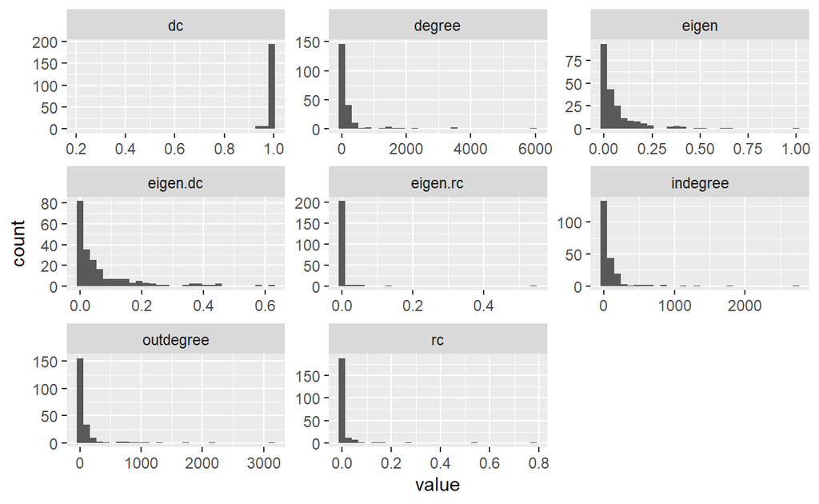

```r
trade.nodes%>%
  select(-name) %>%
  gather() %>%
  ggplot(aes(value)) +
    geom_histogram() +
    facet_wrap(~key, scales = "free")
```

```r
temp<-trade.nodes %>%
  select(degree,indegree,outdegree,eigen,eigen.rc,eigen.dc)%>%
  correlate() %>%
  rearrange()
```

```r
fashion(temp)
```

```
       term eigen.dc eigen degree indegree outdegree eigen.rc
1  eigen.dc            .96    .84      .85       .82      .39
2     eigen      .96          .94      .95       .91      .63
3    degree      .84   .94             .99       .99      .75
4  indegree      .85   .95    .99                .96      .77
5 outdegree      .82   .91    .99      .96                .72
6  eigen.rc      .39   .63    .75      .77       .72
```

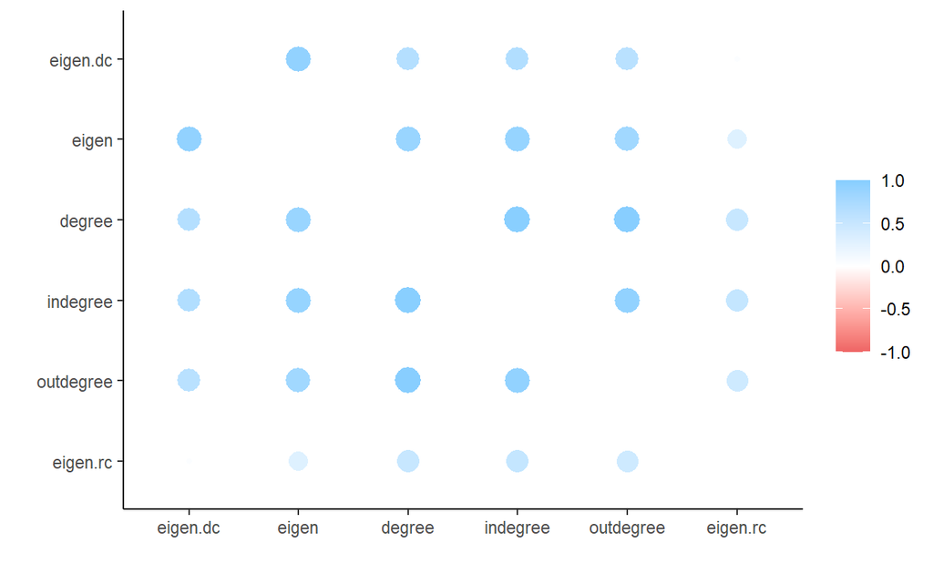

```r
rplot(temp)
```

##Network Brokerage

```r
trade.nodes$close<-sna::closeness(network, gmode="graph", cmode="directed")
trade.nodes%>%
  arrange(desc(close))%>%
  slice(1:5)
```

```
           name degree indegree outdegree     eigen         rc
China     China   5955     2725      3130 1.0000000 0.54089101
Germany Germany   3575     1815      1760 0.6629672 0.06123362
USA         USA   3518     1319      2199 0.6151251 0.05928166
India     India   2177      862      1315 0.4693189 0.04699940
Japan     Japan   1781     1153       628 0.5107358 0.25897033
          eigen.rc        dc  eigen.dc     close
China   0.54089101 0.4591090 0.4591090 0.8406375
Germany 0.04059588 0.9387664 0.6223713 0.8178295
USA     0.03646564 0.9407183 0.5786595 0.7757353
India   0.02205771 0.9530006 0.4472612 0.7429577
Japan   0.13226542 0.7410297 0.3784704 0.7033333
```

##Closeness centralization

```r
igraph::centr_clo(net.ig)$centralization
```

```
[1] NaN
```

##Betweeness centrality

```r
E(net.ig)$weight <- 2**((E(net.ig)$weight - min(E(net.ig)$weight)) / diff(range(E(net.ig)$weight)))
head(estimate_betweenness(net.ig, cutoff = -1))
```

```
     Chile    Germany      Japan      Congo        USA      China
  335.5833  7729.3615  1095.0000     3.0000  7450.0000 12725.5488
```

##Betweeness centralization

```r
centr_betw(net.ig,directed=T)$centralization
```

```
[1] 0.3709939
```

##Network Constraint

```r
trade.nodes$constraint<-constraint(net.ig)
head(trade.nodes)
```

```
           name degree indegree outdegree      eigen           rc
Chile     Chile   1527      570       935 0.37798040 2.029506e-02
Germany Germany   3575     1815      1760 0.66296717 6.123362e-02
Japan     Japan   1781     1153       628 0.51073579 2.589703e-01
Congo     Congo     74       21        53 0.01237694 1.712321e-05
USA         USA   3518     1319      2199 0.61512512 5.928166e-02
China     China   5955     2725      3130 1.00000000 5.408910e-01
            eigen.rc        dc   eigen.dc     close constraint
Chile   7.671134e-03 0.9797049 0.37030927 0.6011396 0.16862104
Germany 4.059588e-02 0.9387664 0.62237129 0.8178295 0.12022799
Japan   1.322654e-01 0.7410297 0.37847037 0.7033333 0.16768130
Congo   2.119329e-07 0.9999829 0.01237672 0.5171569 0.24269425
USA     3.646564e-02 0.9407183 0.57865948 0.7757353 0.12060228
China   5.408910e-01 0.4591090 0.45910899 0.8406375 0.08647505
```

```r
temp <-data.frame(brokerage(network, cl = trade.nodes$name)$z.nlo)
```

```r
trade.nodes<-trade.nodes %>%
  mutate(broker.tot = temp$t,
         broker.coord = temp$w_I,
         broker.itin = temp$w_O,
         broker.rep = temp$b_IO,
         broker.gate = temp$b_OI,
         broker.lia = temp$b_O)
head(trade.nodes)
```

```
           name degree indegree outdegree      eigen           rc
Chile     Chile   1527      570       935 0.37798040 2.029506e-02
Germany Germany   3575     1815      1760 0.66296717 6.123362e-02
Japan     Japan   1781     1153       628 0.51073579 2.589703e-01
Congo     Congo     74       21        53 0.01237694 1.712321e-05
USA         USA   3518     1319      2199 0.61512512 5.928166e-02
China     China   5955     2725      3130 1.00000000 5.408910e-01
            eigen.rc        dc   eigen.dc     close constraint
Chile   7.671134e-03 0.9797049 0.37030927 0.6011396 0.16862104
Germany 4.059588e-02 0.9387664 0.62237129 0.8178295 0.12022799
Japan   1.322654e-01 0.7410297 0.37847037 0.7033333 0.16768130
Congo   2.119329e-07 0.9999829 0.01237672 0.5171569 0.24269425
USA     3.646564e-02 0.9407183 0.57865948 0.7757353 0.12060228
China   5.408910e-01 0.4591090 0.45910899 0.8406375 0.08647505
```

##Authority

```r
trade.nodes$authority <- authority_score(net.ig)$vector

a <- trade.nodes %>%
  arrange(desc(authority))
head(a)
```

```
           name degree indegree outdegree     eigen         rc
China     China   5955     2725      3130 1.0000000 0.54089101
Germany Germany   3575     1815      1760 0.6629672 0.06123362
USA         USA   3518     1319      2199 0.6151251 0.05928166
Japan     Japan   1781     1153       628 0.5107358 0.25897033
India     India   2177      862      1315 0.4693189 0.04699940
Canada   Canada   1411      694       689 0.4283164 0.06661350
          eigen.rc        dc  eigen.dc     close constraint authority
China   0.54089101 0.4591090 0.4591090 0.8406375 0.08647505 1.0000000
Germany 0.04059588 0.9387664 0.6223713 0.8178295 0.12022799 0.6718633
USA     0.03646564 0.9407183 0.5786595 0.7757353 0.12060228 0.6042264
Japan   0.13226542 0.7410297 0.3784704 0.7033333 0.16768130 0.5409779
India   0.02205771 0.9530006 0.4472612 0.7429577 0.14303636 0.4978602
Canada  0.02853166 0.9333865 0.3997847 0.6393939 0.16538251 0.4613137
```

##Hub

```r
trade.nodes$hub_score <- hub_score(net.ig)$vector
head(trade.nodes)
```

```
           name degree indegree outdegree      eigen           rc
Chile     Chile   1527      570       935 0.37798040 2.029506e-02
Germany Germany   3575     1815      1760 0.66296717 6.123362e-02
Japan     Japan   1781     1153       628 0.51073579 2.589703e-01
Congo     Congo     74       21        53 0.01237694 1.712321e-05
USA         USA   3518     1319      2199 0.61512512 5.928166e-02
China     China   5955     2725      3130 1.00000000 5.408910e-01
            eigen.rc        dc   eigen.dc     close constraint
Chile   7.671134e-03 0.9797049 0.37030927 0.6011396 0.16862104
Germany 4.059588e-02 0.9387664 0.62237129 0.8178295 0.12022799
Japan   1.322654e-01 0.7410297 0.37847037 0.7033333 0.16768130
Congo   2.119329e-07 0.9999829 0.01237672 0.5171569 0.24269425
USA     3.646564e-02 0.9407183 0.57865948 0.7757353 0.12060228
China   5.408910e-01 0.4591090 0.45910899 0.8406375 0.08647505
         authority  hub_score
Chile   0.41047729 0.51616040
Germany 0.67186333 0.59688054
Japan   0.54097789 0.36008263
Congo   0.01270362 0.04532019
USA     0.60422644 0.87917344
China   1.00000000 1.00000000
```

##Bridge

```r
bridges(net.ig)
```

```
+ 14/22269 edges from e1fe41a (vertex names):
 [1] United States Minor Outlying Islands  ->Canada
 [2] Canada                                ->Saint Pierre and Miquelon
 [3] Netherlands                           ->Bunkers
 [4] Australia                             ->Solomon Isds
 [5] North America and Central America, nes->China
 [6] FS Micronesia                         ->China
 [7] China                                 ->South Sudan
 [8] China                                 ->Comoros
 [9] USA                                   ->Cocos Isds
[10] USA                                   ->French Polynesia
+ ... omitted several edges
```

```r
bridges <- trade.nodes %>%
  filter(name == "USA")
head(bridges)
```

```
    name degree indegree outdegree     eigen         rc   eigen.rc
USA  USA   3518     1319      2199 0.6151251 0.05928166 0.03646564
           dc  eigen.dc     close constraint authority hub_score
USA 0.9407183 0.5786595 0.7757353  0.1206023 0.6042264 0.8791734
```

##Structural Equivalence

```r
trade.se<-equiv.clust(matrix, equiv.fun="sedist", method="hamming",mode="graph")
summary(trade.se)
```

```
               Length Class  Mode
cluster          7    hclust list
metric           1    -none- character
equiv.fun        1    -none- character
cluster.method   1    -none- character
glabels        212    -none- character
plabels        212    -none- character
```

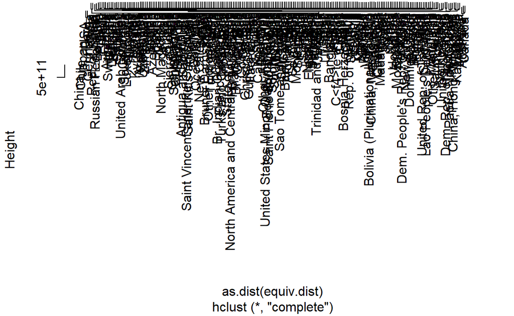

```r
plot(trade.se, labels=trade.se$glabels)
```

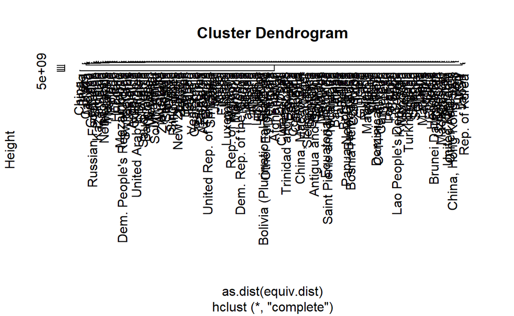

```r
library(igraph)
library(sna)
X_graphite <- data.frame("From" = graphite_trade_clean$reporter,
                "To" = graphite_trade_clean$partner,
                "weight" = graphite_trade_clean$trade_value_usd)

net_graphite.ig <- graph_from_data_frame(X_graphite, directed = TRUE)

matrix_graphite <- as.matrix(as_adjacency_matrix(net_graphite.ig, attr = "weight"))

trade_graphite.se <- equiv.clust(matrix_graphite, equiv.fun="sedist", method="hamming",mode="graph")

plot(trade_graphite.se, labels=trade_graphite.se$glabels)
```

```r
#library(ggdendro)

#ggdendrogram(trade.se, rotate = FALSE, size = 2)
```

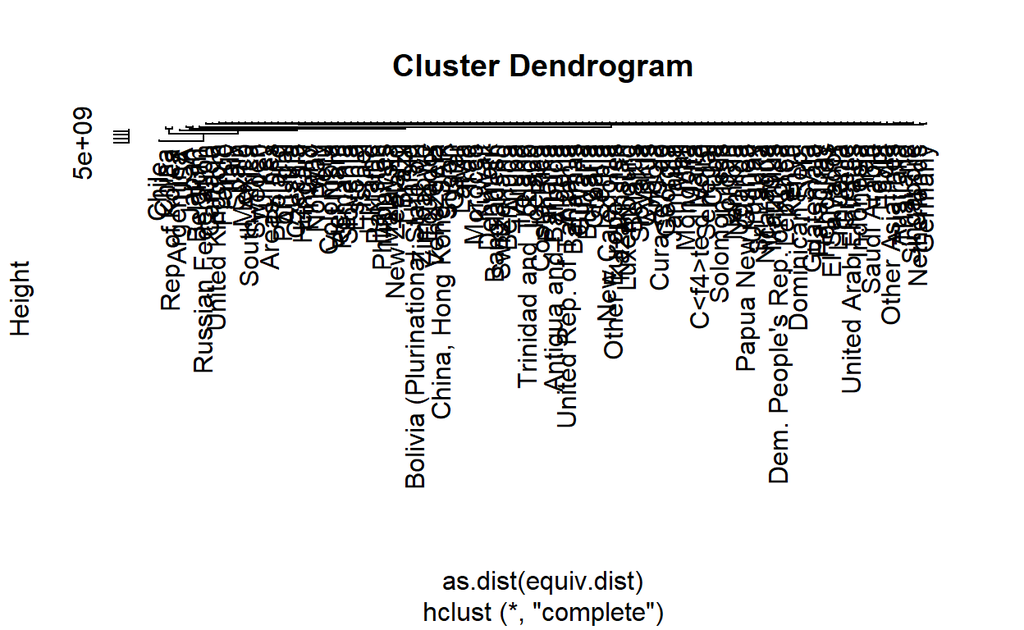

```r
X_lithium <- data.frame("From" = lithium_trade_clean$reporter,
                "To" = lithium_trade_clean$partner,
                "weight" = lithium_trade_clean$trade_value_usd)

net_lithium.ig <- graph_from_data_frame(X_lithium, directed = TRUE)

matrix_lithium <- as.matrix(as_adjacency_matrix(net_lithium.ig, attr = "weight"))

trade_lithium.se <- equiv.clust(matrix_lithium, equiv.fun="sedist", method="hamming",mode="graph")

plot(trade_lithium.se, labels=trade_lithium.se$glabels)
```

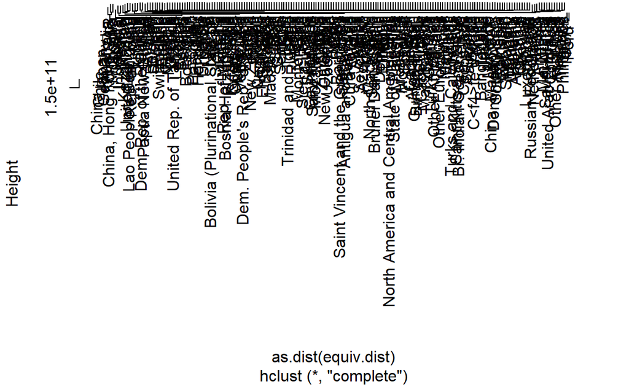

```r
X_copper <- data.frame("From" = copper_trade_clean$reporter,
                "To" = copper_trade_clean$partner,
                "weight" = copper_trade_clean$trade_value_usd)

net_copper.ig <- graph_from_data_frame(X_copper, directed = TRUE)

matrix_copper <- as.matrix(as_adjacency_matrix(net_copper.ig, attr = "weight"))

trade_copper.se <- equiv.clust(matrix_copper, equiv.fun="sedist", method="hamming",mode="graph")

plot(trade_copper.se, labels=trade_copper.se$glabels)
```

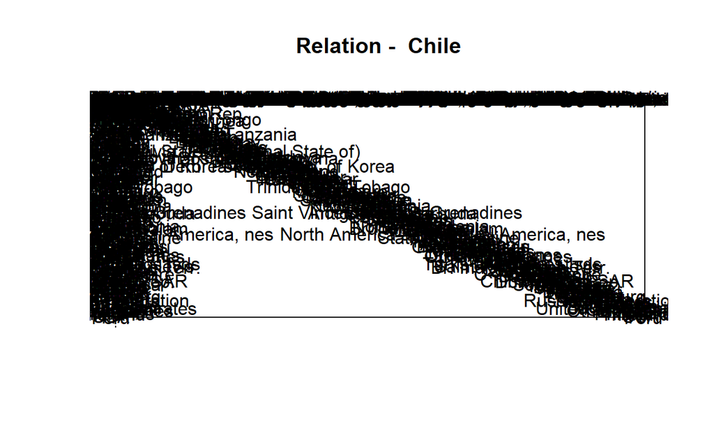

```r
blk_copper_model <- blockmodel(matrix, trade_copper.se, k = 2)
plot(blk_copper_model)
```

```r
plot.block <- function(x = blk_copper_model, main = NULL, cex.lab =1){
  plot.sociomatrix(x$blocked.data, labels = list(x$plabels,x$plabels),
                   main = main, drawlines = FALSE, cex.lab = cex.lab)
  for (i in 2: length(x$plabels)) if (x$block.membership[i] !=
                                      x$block.membership[i-1])
    abline(v = i - 0.5, h = i - 0.5, lty = 3, xpd = FALSE)
}
```

```r
blk_copper_model <- blockmodel(matrix, trade_copper.se, k = 5)
blk_copper_model$block.model
```

```
          Block 1    Block 2     Block 3   Block 4     Block 5
Block 1       0.0 2127081834 19556797178 141680857 39379591089
Block 2  466224.5          0    26636007  39476769  2333749724
Block 3   30123.0    1288701           0   6122243  4036226234
Block 4 5246127.4  130414080   173674436   1405752   623226200
Block 5  421052.8   98436068   881452178  19146694           0
```

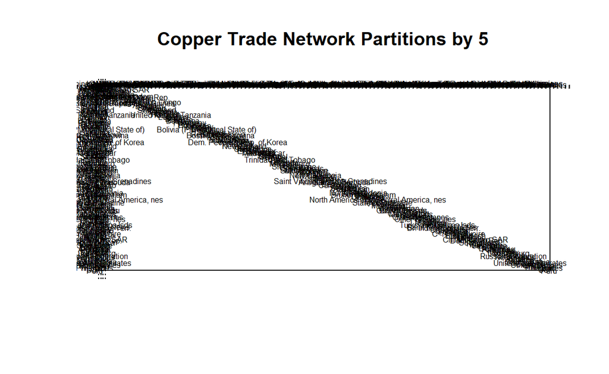

```r
plot.block(blk_copper_model, main = "Copper Trade Network Partitions by 5", cex.lab = 0.5)
```

##Community Detection

```r
net.ig.undirected <- as.undirected(net.ig)
names(cluster_fast_greedy(net.ig.undirected))
```

```
[1] "merges"     "modularity" "membership" "names"      "algorithm"
[6] "vcount"
```

```r
cluster_fast_greedy(net.ig.undirected)
```

```
IGRAPH clustering fast greedy, groups: 3, mod: 0.15
+ groups:
  $`1`
   [1] "Germany"               "Russian Federation"
   [3] "Portugal"              "Netherlands"
   [5] "Belgium"               "Ukraine"
   [7] "Bulgaria"              "Austria"
   [9] "Finland"               "Poland"
  [11] "Italy"                 "Sweden"
  [13] "Kazakhstan"            "Turkey"
  [15] "Armenia"               "Azerbaijan"
  [17] "Bosnia Herzegovina"    "Belarus"
  + ... omitted several groups/vertices
```

```r
igraph::groups(cluster_fast_greedy(net.ig.undirected))
```

```
$`1`
 [1] "Germany"               "Russian Federation"
 [3] "Portugal"              "Netherlands"
 [5] "Belgium"               "Ukraine"
 [7] "Bulgaria"              "Austria"
 [9] "Finland"               "Poland"
[11] "Italy"                 "Sweden"
[13] "Kazakhstan"            "Turkey"
[15] "Armenia"               "Azerbaijan"
[17] "Bosnia Herzegovina"    "Belarus"
[19] "Croatia"               "Cyprus"
[21] "Czechia"               "Denmark"
[23] "Estonia"               "Faeroe Isds"
[25] "Georgia"               "Greece"
[27] "Hungary"               "Iceland"
```

[output cut: 174 more lines]

Exploring Community Density

```r
print(blockmodel(matrix, cluster_fast_greedy(net.ig.undirected)$membership)$block.model, digits = 2)
```

```
        Block 1 Block 2 Block 3
Block 1 1.1e+07 7.9e+05 6.7e+06
Block 2 1.3e+07 4.0e+07 6.0e+07
Block 3 1.4e+06 8.5e+06 1.1e+07
```

```r
cluster_fast_greedy(net.ig.undirected)$membership
```

```
  [1] 2 1 2 3 2 3 3 1 3 2 2 3 1 1 1 3 2 2 1 2 1 2 3 2 2 2 1 1 3 2 2 3
 [33] 3 2 1 2 1 1 2 1 3 3 3 1 3 3 3 3 3 3 2 2 3 1 3 3 3 3 1 2 3 1 1 3
 [65] 2 1 3 1 1 3 1 1 1 3 1 1 2 2 2 1 1 1 1 1 3 3 3 1 3 1 1 1 3 1 1 1
 [97] 3 2 3 1 3 2 2 1 3 1 3 1 1 1 1 3 2 3 2 3 3 1 3 3 2 1 2 3 3 3 3 2
[129] 1 1 3 3 1 3 3 2 2 2 3 2 3 3 3 3 2 3 2 3 3 3 3 2 2 2 2 2 2 3 2 3
[161] 2 2 2 2 2 2 2 2 3 3 3 3 3 2 3 3 3 3 3 3 3 1 1 1 3 3 1 3 2 2 3 3
[193] 3 3 2 2 1 1 2 2 3 3 2 2 2 2 2 3 1 3 2 2
```

```r
cluster_fast_greedy(net.ig.undirected)$names
```

```
  [1] "Chile"
  [2] "Germany"
  [3] "Japan"
  [4] "Congo"
  [5] "USA"
  [6] "China"
  [7] "Zambia"
  [8] "Russian Federation"
  [9] "Australia"
 [10] "Argentina"
 [11] "Brazil"
 [12] "Zimbabwe"
 [13] "Portugal"
 [14] "Netherlands"
 [15] "Belgium"
```

[output cut: 197 more lines]

```r
membership(cluster_fast_greedy(net.ig.undirected))
```

```
                                 Chile
                                     2
                               Germany
                                     1
                                 Japan
                                     2
                                 Congo
                                     3
                                   USA
                                     2
                                 China
                                     3
                                Zambia
                                     3
                    Russian Federation
                                     1
                             Australia
                                     3
                             Argentina
                                     2
                                Brazil
                                     2
                              Zimbabwe
                                     3
                              Portugal
                                     1
                           Netherlands
                                     1
                               Belgium
                                     1
                                 India
                                     3
                                Canada
                                     2
                                Mexico
                                     2
                               Ukraine
                                     1
      Bolivia (Plurinational State of)
                                     2
```

[output cut: 369 more lines]

```
                                     2
                                Tuvalu
                                     2
                         Guinea-Bissau
                                     2
                          Solomon Isds
                                     3
                               Bunkers
                                     1
                               Comoros
                                     3
                     Equatorial Guinea
                                     2
             Saint Pierre and Miquelon
                                     2
```

```r
V(net.ig)$name
```

```
  [1] "Chile"
  [2] "Germany"
  [3] "Japan"
  [4] "Congo"
  [5] "USA"
  [6] "China"
  [7] "Zambia"
  [8] "Russian Federation"
  [9] "Australia"
 [10] "Argentina"
 [11] "Brazil"
 [12] "Zimbabwe"
 [13] "Portugal"
 [14] "Netherlands"
 [15] "Belgium"
```

[output cut: 197 more lines]

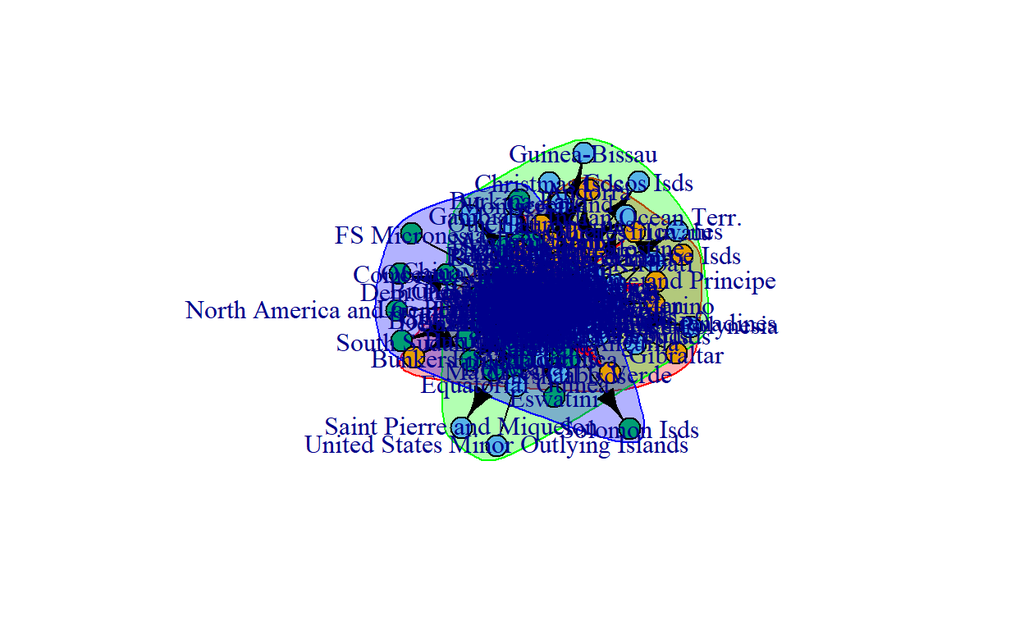

```r
plot(cluster_fast_greedy(net.ig.undirected), net.ig)
```

```r
trade.wt <- walktrap.community(net.ig)
```

```r
igraph::groups(trade.wt)
```

```
$`1`
  [1] "Chile"
  [2] "Germany"
  [3] "Japan"
  [4] "Congo"
  [5] "USA"
  [6] "China"
  [7] "Zambia"
  [8] "Russian Federation"
  [9] "Australia"
 [10] "Argentina"
 [11] "Brazil"
 [12] "Zimbabwe"
 [13] "Portugal"
 [14] "Netherlands"
```

[output cut: 198 more lines]

```r
igraph::groups(walktrap.community(net.ig, steps = 10))
```

```
$`1`
  [1] "Chile"
  [2] "Germany"
  [3] "Japan"
  [4] "Congo"
  [5] "USA"
  [6] "China"
  [7] "Zambia"
  [8] "Russian Federation"
  [9] "Australia"
 [10] "Argentina"
 [11] "Brazil"
 [12] "Zimbabwe"
 [13] "Portugal"
 [14] "Netherlands"
```

[output cut: 198 more lines]

```r
igraph::groups(walktrap.community(net.ig, steps = 20))
```

```
$`1`
  [1] "Chile"
  [2] "Germany"
  [3] "Japan"
  [4] "Congo"
  [5] "USA"
  [6] "China"
  [7] "Zambia"
  [8] "Russian Federation"
  [9] "Australia"
 [10] "Argentina"
 [11] "Brazil"
 [12] "Zimbabwe"
 [13] "Portugal"
 [14] "Netherlands"
```

[output cut: 198 more lines]

```r
igraph::groups(walktrap.community(net.ig, steps = 100))
```

```
$`1`
  [1] "Chile"
  [2] "Germany"
  [3] "Japan"
  [4] "Congo"
  [5] "USA"
  [6] "China"
  [7] "Zambia"
  [8] "Russian Federation"
  [9] "Australia"
 [10] "Argentina"
 [11] "Brazil"
 [12] "Zimbabwe"
 [13] "Portugal"
 [14] "Netherlands"
```

[output cut: 198 more lines]

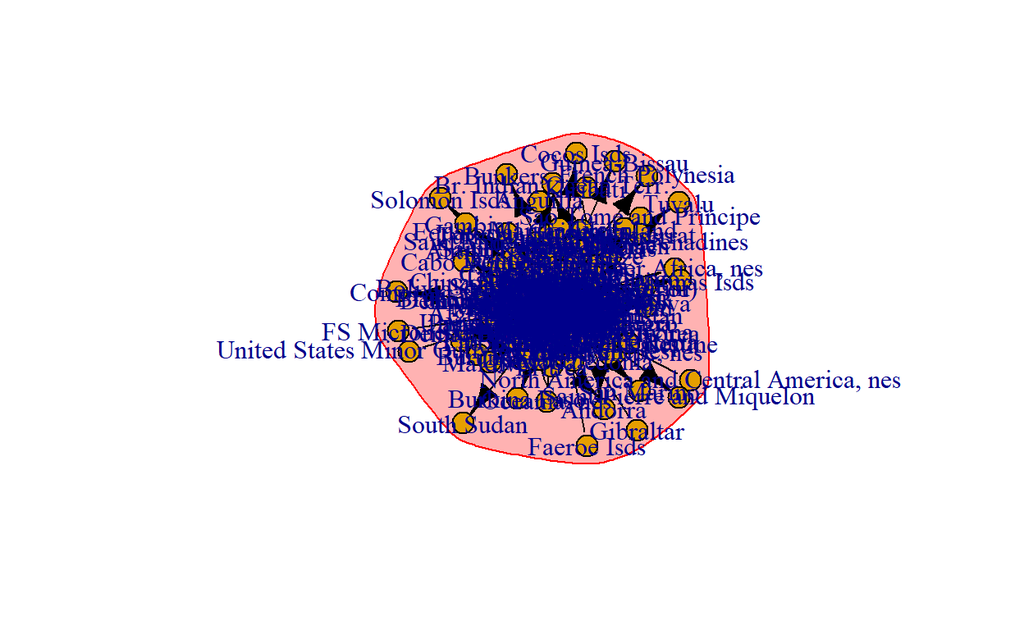

```r
plot(trade.wt, net.ig)
```

```r
modularity(cluster_fast_greedy(net.ig.undirected))
```

```
[1] 0.154595
```

```r
modularity(trade.wt)
```

```
[1] 0.00353056
```

```r
compare.algs<-function(alg.a,alg.b,compare.meth=c("vi", "nmi", "split.join", "rand", "adjusted.rand")){
  #create list of community objects and methods
  comm.compare<-expand.grid(alg.a=alg.a, alg.b=alg.b, meth=compare.meth, result=NA, stringsAsFactors = FALSE)
  #compare community partitions using a loop
for(i in 1:nrow(comm.compare)){
  comm1<-get(comm.compare$alg.a[i])
  comm2<-get(comm.compare$alg.b[i])
  method<-comm.compare$meth[i]
  comm.compare$result[i]<-compare(comm1, comm2, method)
}
  return(comm.compare)
}
```

```r
#compare community partitions
trade.fg <- cluster_fast_greedy(net.ig.undirected)
compare.algs(alg.a=c("trade.fg"),alg.b="trade.wt")
```

```
     alg.a    alg.b          meth        result
1 trade.fg trade.wt            vi  1.082181e+00
2 trade.fg trade.wt           nmi  0.000000e+00
3 trade.fg trade.wt    split.join  1.240000e+02
4 trade.fg trade.wt          rand  3.413664e-01
5 trade.fg trade.wt adjusted.rand -8.428229e-17
```